# Multivariate Analysis Midterm

DA 410

Marjorie Blanco

## Problem 4

In the following table, we have a comparison of four reagents. The first reagent is the one presently in use and the other three are less expensive reagents that we wish to compare with the first. All four reagents are used with a blood sample from each patient.

```r
reagents <- read_table2("Software-Files/T6_19_REAGENT.DAT", col_names =  c("Reagent", "Subject" ,
                                                                       "white.blood.count",
                                                                       "red.blood.count",
                                                                       "hemoglobin.count"),
                    cols(Reagent = col_integer(),
                         Subject = col_integer(),
                         white.blood.count = col_double(),
                         red.blood.count = col_double(),
                         hemoglobin.count = col_double()))
```

The three variables measured for each reagent are $y_1$ = white blood count, $y_2$ = red blood count, and $y_3$ = hemoglobin count.

| Reagent | Subject | white.blood.count | red.blood.count | hemoglobin.count |
| --- | --- | --- | --- | --- |
| 1 | 1 | 8.0 | 3.96 | 12.5 |
| 1 | 2 | 4.0 | 5.37 | 16.9 |
| 1 | 3 | 6.3 | 5.47 | 17.1 |
| 1 | 4 | 9.4 | 5.16 | 16.2 |
| 1 | 5 | 8.2 | 5.16 | 17.0 |
| 1 | 6 | 11.0 | 4.67 | 14.3 |
| 1 | 7 | 6.8 | 5.20 | 16.2 |
| 1 | 8 | 9.0 | 4.65 | 14.7 |
| 1 | 9 | 6.1 | 5.22 | 16.3 |
| 1 | 10 | 6.4 | 5.13 | 15.9 |
| 1 | 11 | 5.6 | 4.47 | 13.3 |
| 1 | 12 | 8.2 | 5.22 | 16.0 |
| 1 | 13 | 5.7 | 5.10 | 14.9 |
| 1 | 14 | 9.8 | 5.25 | 16.1 |
| 1 | 15 | 5.9 | 5.28 | 15.8 |
| 1 | 16 | 6.6 | 4.65 | 12.8 |
| 1 | 17 | 5.7 | 4.42 | 14.5 |
| 1 | 18 | 6.7 | 4.38 | 13.1 |
| 1 | 19 | 6.8 | 4.67 | 15.6 |
| 1 | 20 | 9.6 | 5.64 | 17.0 |
| 2 | 1 | 8.0 | 3.93 | 12.7 |
| 2 | 2 | 4.2 | 5.35 | 17.2 |
| 2 | 3 | 6.3 | 5.39 | 17.5 |
| 2 | 4 | 9.4 | 5.16 | 16.7 |
| 2 | 5 | 8.0 | 5.13 | 17.5 |
| 2 | 6 | 10.7 | 4.60 | 14.7 |
| 2 | 7 | 6.8 | 5.16 | 16.7 |
| 2 | 8 | 9.0 | 4.57 | 15.0 |
| 2 | 9 | 6.0 | 5.16 | 16.9 |
| 2 | 10 | 6.4 | 5.11 | 16.4 |
| 2 | 11 | 5.5 | 4.45 | 13.6 |
| 2 | 12 | 8.2 | 5.14 | 16.5 |
| 2 | 13 | 5.6 | 5.05 | 15.3 |
| 2 | 14 | 9.8 | 5.15 | 16.6 |
| 2 | 15 | 5.8 | 5.25 | 16.4 |
| 2 | 16 | 6.4 | 4.59 | 13.2 |
| 2 | 17 | 5.5 | 4.31 | 14.9 |
| 2 | 18 | 6.5 | 4.32 | 13.4 |
| 2 | 19 | 6.6 | 4.57 | 15.8 |
| 2 | 20 | 9.5 | 5.58 | 17.5 |
| 3 | 1 | 7.9 | 3.86 | 13.0 |
| 3 | 2 | 4.1 | 5.39 | 17.2 |
| 3 | 3 | 6.0 | 5.39 | 17.2 |
| 3 | 4 | 9.4 | 5.17 | 16.7 |
| 3 | 5 | 8.1 | 5.10 | 17.4 |
| 3 | 6 | 10.6 | 4.52 | 14.6 |
| 3 | 7 | 6.9 | 5.13 | 16.8 |
| 3 | 8 | 8.9 | 4.58 | 15.0 |
| 3 | 9 | 6.1 | 5.14 | 16.9 |
| 3 | 10 | 6.4 | 5.11 | 16.4 |
| 3 | 11 | 5.3 | 4.46 | 13.6 |
| 3 | 12 | 8.0 | 5.14 | 16.5 |
| 3 | 13 | 5.5 | 5.02 | 15.4 |
| 3 | 14 | 8.1 | 5.10 | 13.8 |
| 3 | 15 | 5.7 | 5.26 | 16.4 |
| 3 | 16 | 6.3 | 4.58 | 13.1 |
| 3 | 17 | 5.5 | 4.30 | 14.9 |
| 3 | 18 | 6.5 | 4.32 | 13.6 |
| 3 | 19 | 6.5 | 4.55 | 16.0 |
| 3 | 20 | 9.3 | 5.50 | 17.4 |
| 4 | 1 | 7.9 | 3.87 | 13.2 |
| 4 | 2 | 4.0 | 5.35 | 17.3 |
| 4 | 3 | 6.1 | 5.41 | 17.4 |
| 4 | 4 | 9.1 | 5.16 | 16.7 |
| 4 | 5 | 7.8 | 5.12 | 17.5 |
| 4 | 6 | 10.5 | 4.58 | 14.7 |
| 4 | 7 | 6.7 | 5.19 | 16.8 |
| 4 | 8 | 8.6 | 4.55 | 15.1 |
| 4 | 9 | 6.0 | 5.21 | 16.9 |
| 4 | 10 | 6.3 | 5.07 | 16.3 |
| 4 | 11 | 5.3 | 4.44 | 13.7 |
| 4 | 12 | 7.8 | 5.16 | 16.5 |
| 4 | 13 | 5.4 | 5.05 | 15.5 |
| 4 | 14 | 9.4 | 5.16 | 16.6 |
| 4 | 15 | 5.6 | 5.29 | 16.2 |
| 4 | 16 | 6.4 | 4.57 | 13.2 |
| 4 | 17 | 5.4 | 4.32 | 14.8 |
| 4 | 18 | 6.5 | 4.31 | 13.5 |
| 4 | 19 | 6.5 | 4.56 | 15.9 |
| 4 | 20 | 9.2 | 5.46 | 17.5 |

Compare the four reagents using all four MANOVA tests. State each hypotheses clearly, and interpret the results.

```r
reagents %>%  dplyr::select(-Subject) %>% split(.$Reagent) %>% map(summary)
```

```
## $`1`
##     Reagent  white.blood.count red.blood.count hemoglobin.count
##  Min.   :1   Min.   : 4.00     Min.   :3.960   Min.   :12.50
##  1st Qu.:1   1st Qu.: 6.05     1st Qu.:4.650   1st Qu.:14.45
##  Median :1   Median : 6.75     Median :5.145   Median :15.85
##  Mean   :1   Mean   : 7.29     Mean   :4.954   Mean   :15.31
##  3rd Qu.:1   3rd Qu.: 8.40     3rd Qu.:5.228   3rd Qu.:16.23
##  Max.   :1   Max.   :11.00     Max.   :5.640   Max.   :17.10
##
## $`2`
##     Reagent  white.blood.count red.blood.count hemoglobin.count
##  Min.   :2   Min.   : 4.20     Min.   :3.930   Min.   :12.70
##  1st Qu.:2   1st Qu.: 5.95     1st Qu.:4.570   1st Qu.:14.85
##  Median :2   Median : 6.55     Median :5.120   Median :16.40
##  Mean   :2   Mean   : 7.21     Mean   :4.899   Mean   :15.72
##  3rd Qu.:2   3rd Qu.: 8.40     3rd Qu.:5.160   3rd Qu.:16.75
##  Max.   :2   Max.   :10.70     Max.   :5.580   Max.   :17.50
##
## $`3`
##     Reagent  white.blood.count red.blood.count hemoglobin.count
##  Min.   :3   Min.   : 4.100    Min.   :3.860   Min.   :13.00
##  1st Qu.:3   1st Qu.: 5.925    1st Qu.:4.543   1st Qu.:14.40
##  Median :3   Median : 6.500    Median :5.100   Median :16.20
##  Mean   :3   Mean   : 7.055    Mean   :4.881   Mean   :15.60
##  3rd Qu.:3   3rd Qu.: 8.100    3rd Qu.:5.147   3rd Qu.:16.82
##  Max.   :3   Max.   :10.600    Max.   :5.500   Max.   :17.40
##
## $`4`
##     Reagent  white.blood.count red.blood.count hemoglobin.count
##  Min.   :4   Min.   : 4.000    Min.   :3.870   Min.   :13.20
##  1st Qu.:4   1st Qu.: 5.900    1st Qu.:4.558   1st Qu.:14.78
##  Median :4   Median : 6.500    Median :5.095   Median :16.25
##  Mean   :4   Mean   : 7.025    Mean   :4.891   Mean   :15.77
##  3rd Qu.:4   3rd Qu.: 8.075    3rd Qu.:5.195   3rd Qu.:16.82
##  Max.   :4   Max.   :10.500    Max.   :5.460   Max.   :17.50
```

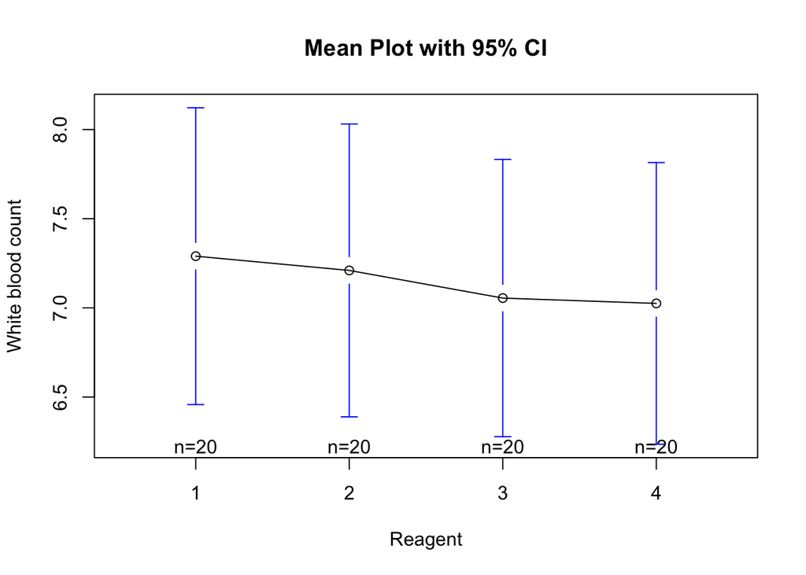

```r
plotmeans(white.blood.count ~ Reagent, data = reagents,
          xlab = "Reagent", ylab = "White blood count",
          main="Mean Plot with 95% CI")
```

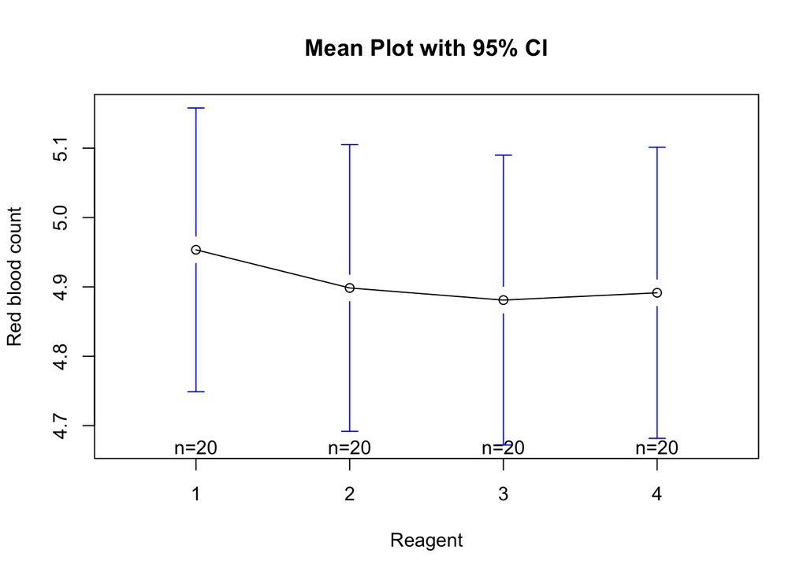

```r
plotmeans(red.blood.count ~ Reagent, data = reagents,
          xlab = "Reagent", ylab = "Red blood count",
          main="Mean Plot with 95% CI")
```

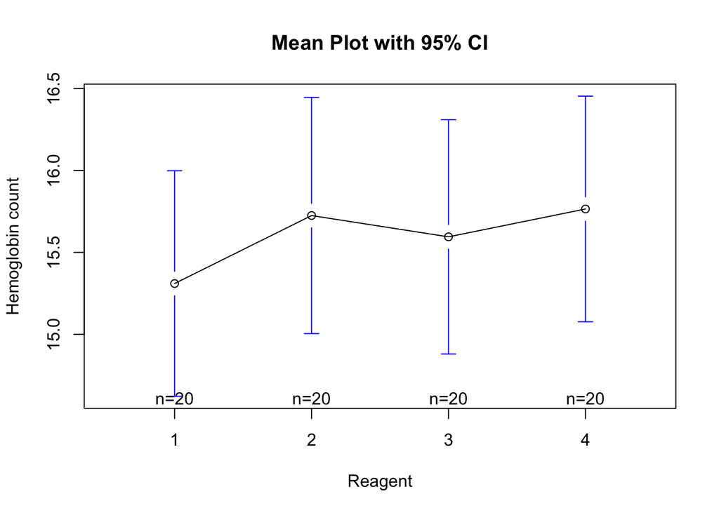

```r
plotmeans(hemoglobin.count ~ Reagent, data = reagents,
          xlab = "Reagent", ylab = "Hemoglobin count",
          main="Mean Plot with 95% CI")
```

The overall mean vector:

|  | x |
| --- | --- |
| white.blood.count | 7.145000 |
| red.blood.count | 4.906125 |
| hemoglobin.count | 15.598750 |

|  | 1 | 2 | 3 | 4 |
| --- | --- | --- | --- | --- |
| white.blood.count | 7.2900 | 7.2100 | 7.055 | 7.0250 |
| red.blood.count | 4.9535 | 4.8985 | 4.881 | 4.8915 |
| hemoglobin.count | 15.3100 | 15.7250 | 15.595 | 15.7650 |

H =

| 0.9550 | 0.2078000 | -1.0655000 |
| --- | --- | --- |
| 0.2078 | 0.0629537 | -0.3395875 |
| -1.0655 | -0.3395875 | 2.5393750 |

E =

| 225.16300 | -0.91085 | 6.0200 |
| --- | --- | --- |
| -0.91085 | 14.92915 | 44.5492 |
| 6.02000 | 44.54920 | 171.6705 |

k = 4

p = 3

$_vH$ = 3

$_vE$ = 76

t = 2.4337372

$df_1$ = 9

$df_2$ = 180.2471612

F = 1.1529191

```r
# MANOVA test
reagents.manova <- manova(cbind(reagents$white.blood.count, reagents$red.blood.count, reagents$hemoglobin.count) ~ Reagent, data = reagents)
reagents.summary <- summary(reagents.manova)
reagents.summary
```

```
##           Df   Pillai approx F num Df den Df  Pr(>F)
## Reagent    1 0.086561   2.4007      3     76 0.07431 .
## Residuals 78
## ---
## Signif. codes:  0 '***' 0.001 '**' 0.01 '*' 0.05 '.' 0.1 ' ' 1
```

```r
# Look to see which differ
summary.aov(reagents.manova)
```

```
##  Response 1 :
##             Df  Sum Sq Mean Sq F value Pr(>F)
## Reagent      1   0.903  0.9025  0.3126 0.5777
## Residuals   78 225.216  2.8874
##
##  Response 2 :
##             Df  Sum Sq  Mean Sq F value Pr(>F)
## Reagent      1  0.0414 0.041412  0.2161 0.6434
## Residuals   78 14.9507 0.191675
##
##  Response 3 :
##             Df  Sum Sq Mean Sq F value Pr(>F)
## Reagent      1   1.525  1.5252  0.6889 0.4091
## Residuals   78 172.685  2.2139
```

```r
reagents.summary$SS
```

```
## $Reagent
##           [,1]        [,2]       [,3]
## [1,]  0.902500  0.19332500 -1.1732500
## [2,]  0.193325  0.04141225 -0.2513225
## [3,] -1.173250 -0.25132250  1.5252250
##
## $Residuals
##            [,1]      [,2]      [,3]
## [1,] 225.215500 -0.896375   6.12775
## [2,]  -0.896375 14.950687  44.46094
## [3,]   6.127750 44.460935 172.68465
```

## Problem 5

The table below displays scores on math, English, and art tests for 5 students. Note that data from the table is represented in matrix A, where each column in the matrix shows scores on a test and each row shows scores for a student:

```r
A <- matrix(c(90,   60, 90, 90, 90, 30, 60, 60, 60, 60, 60, 90, 30, 30, 30), nrow = 5, ncol = 3, byrow = TRUE )
colnames(A) <- c("Math", "English", "Art")
```

A =

```r
A
```

```
##      Math English Art
## [1,]   90      60  90
## [2,]   90      90  30
## [3,]   60      60  60
## [4,]   60      60  90
## [5,]   30      30  30
```

1. Calculate the sample covariance matrix S.

S =

```r
S <- cov(A)
kable(S, caption = "Sample covariance matrix")
```

Sample covariance matrix

|  | Math | English | Art |
| --- | --- | --- | --- |
| Math | 630 | 450 | 225 |
| English | 450 | 450 | 0 |
| Art | 225 | 0 | 900 |

2. Calculate the sample correlation matrix R.

R =

```r
R <- cor(A)
kable(R, caption = "Sample correlation matrix")
```

Sample correlation matrix

|  | Math | English | Art |
| --- | --- | --- | --- |
| Math | 1.0000000 | 0.8451543 | 0.2988072 |
| English | 0.8451543 | 1.0000000 | 0.0000000 |
| Art | 0.2988072 | 0.0000000 | 1.0000000 |

## Problem 6:

Use the beetle data, do the following:

```r
beetles <- read.table('Software-Files/T5_5_FBEETLES.DAT', col.names = c('Measurement.Number',
                                                   'Species',
                                                   'transverse.groove.dist', 'elytra.length',
                                                   'second.antennal.joint.length',
                                                   'third.antennal.joint.length'))
```

Beetle =

```r
kable(beetles)
```

| Measurement.Number | Species | transverse.groove.dist | elytra.length | second.antennal.joint.length | third.antennal.joint.length |
| --- | --- | --- | --- | --- | --- |
| 1 | 1 | 189 | 245 | 137 | 163 |
| 2 | 1 | 192 | 260 | 132 | 217 |
| 3 | 1 | 217 | 276 | 141 | 192 |
| 4 | 1 | 221 | 299 | 142 | 213 |
| 5 | 1 | 171 | 239 | 128 | 158 |
| 6 | 1 | 192 | 262 | 147 | 173 |
| 7 | 1 | 213 | 278 | 136 | 201 |
| 8 | 1 | 192 | 255 | 128 | 185 |
| 9 | 1 | 170 | 244 | 128 | 192 |
| 10 | 1 | 201 | 276 | 146 | 186 |
| 11 | 1 | 195 | 242 | 128 | 192 |
| 12 | 1 | 205 | 263 | 147 | 192 |
| 13 | 1 | 180 | 252 | 121 | 167 |
| 14 | 1 | 192 | 283 | 138 | 183 |
| 15 | 1 | 200 | 294 | 138 | 188 |
| 16 | 1 | 192 | 277 | 150 | 177 |
| 17 | 1 | 200 | 287 | 136 | 173 |
| 18 | 1 | 181 | 255 | 146 | 183 |
| 19 | 1 | 192 | 287 | 141 | 198 |
| 1 | 2 | 181 | 305 | 184 | 209 |
| 2 | 2 | 158 | 237 | 133 | 188 |
| 3 | 2 | 184 | 300 | 166 | 231 |
| 4 | 2 | 171 | 273 | 162 | 213 |
| 5 | 2 | 181 | 297 | 163 | 224 |
| 6 | 2 | 181 | 308 | 160 | 223 |
| 7 | 2 | 177 | 301 | 166 | 221 |
| 8 | 2 | 198 | 308 | 141 | 197 |
| 9 | 2 | 180 | 286 | 146 | 214 |
| 10 | 2 | 177 | 299 | 171 | 192 |
| 11 | 2 | 176 | 317 | 166 | 213 |
| 12 | 2 | 192 | 312 | 166 | 209 |
| 13 | 2 | 176 | 285 | 141 | 200 |
| 14 | 2 | 169 | 287 | 162 | 214 |
| 15 | 2 | 164 | 265 | 147 | 192 |
| 16 | 2 | 181 | 308 | 157 | 204 |
| 17 | 2 | 192 | 276 | 154 | 209 |
| 18 | 2 | 181 | 278 | 149 | 235 |
| 19 | 2 | 175 | 271 | 140 | 192 |
| 20 | 2 | 197 | 303 | 170 | 205 |

## Problem 7

Use the above beetle data, do the following:

1. Use LDA by setting probability of 50% and 50% to train model.

```r
beetle.lda <- lda(Species ~ .-Measurement.Number, prior = c(0.5,0.5), data = beetles)
beetle.lda
```

```
## Call:
## lda(Species ~ . - Measurement.Number, data = beetles, prior = c(0.5,
##     0.5))
##
## Prior probabilities of groups:
##   1   2
## 0.5 0.5
##
## Group means:
##   transverse.groove.dist elytra.length second.antennal.joint.length
## 1               194.4737      267.0526                     137.3684
## 2               179.5500      290.8000                     157.2000
##   third.antennal.joint.length
## 1                    185.9474
## 2                    209.2500
##
## Coefficients of linear discriminants:
##                                      LD1
## transverse.groove.dist       -0.09327642
## elytra.length                 0.03522706
## second.antennal.joint.length  0.02875538
## third.antennal.joint.length   0.03872998
```

```r
lda.pred <- predict(beetle.lda)$class
```